# Reproducible Research: Peer Assessment 1

## Loading and preprocessing the data

Load the **libraries**.

```r
library(dplyr)
library(tidyverse)
library(ggplot2)
library(tidyr)
library(data.table)
library(zoo)
```

**Load the data**

```r
setwd("C:/Users/ok/Desktop/Coursera Reproducible Research/Week 2 Assignment/RepData_PeerAssessment1/RepData_PeerAssessment1/activity")
my_data <- read_csv("activity.csv")
data <- my_data
str(data)
```

```
## Classes 'spec_tbl_df', 'tbl_df', 'tbl' and 'data.frame': 17568 obs. of  3 variables:
##  $ steps   : num  NA NA NA NA NA NA NA NA NA NA ...
##  $ date    : Date, format: "2012-10-01" "2012-10-01" ...
##  $ interval: num  0 5 10 15 20 25 30 35 40 45 ...
##  - attr(*, "spec")=
##   .. cols(
##   ..   steps = col_double(),
##   ..   date = col_date(format = ""),
##   ..   interval = col_double()
##   .. )
```

This format is suitable for our analysis.

## What is mean total number of steps taken per day?

Create a new col in the data frame with the total number of steps per day.

```r
data <- data %>% group_by(date) %>% mutate(totsteps = sum(steps, na.rm = TRUE))
```

**Make a histogram of the total number of steps taken each day.**

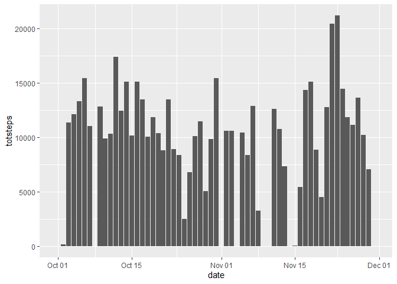

```r
stepsHist <- ggplot(data, aes(date,totsteps))
stepsHist + geom_histogram(stat="identity",position="dodge")
```

```r
data <- data %>% mutate(means = mean(totsteps, na.rm = TRUE))
data <- data %>% mutate(medians = median(totsteps, na.rm = TRUE))
avg <- mean(data$means)
mid <- median(data$medians)
```

## What is the average daily activity pattern?

**Make a time series plot (i.e. type = “l”) of the 5-minute interval (x-axis) and the average number of steps taken, averaged across all days (y-axis)**

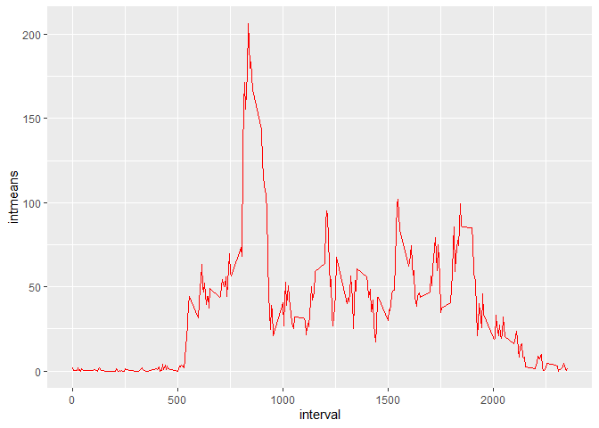

```r
intdata <- my_data %>% group_by(interval) %>% summarise(intmeans = mean(steps, na.rm = TRUE))
iplot <- ggplot(intdata, aes(interval, intmeans))
iplot +geom_line(color = "red")
```

**Which 5-minute interval, on average across all the days in the dataset, contains the maximum number of steps?**

```r
maxinterval <- filter(intdata, intmeans == max(intmeans))
```

So the **interval with the maximum number of steps is 835.**

## Imputing missing values

**Calculate and report the total number of missing values in the dataset (i.e. the total number of rows with NAs)**

```r
nas <- sum(is.na(data$steps))
```

The total number of NA’s is 2304.

**Devise a strategy for filling in all of the missing values in the dataset.**

```r
data2 <- transform(my_data, steps = na.aggregate(steps, by = interval))
```

**Create a new dataset that is equal to the original dataset but with the missing data filled in.**

```r
str(data2)
```

```
## 'data.frame':    17568 obs. of  3 variables:
##  $ steps   : num  1.717 0.3396 0.1321 0.1509 0.0755 ...
##  $ date    : Date, format: "2012-10-01" "2012-10-01" ...
##  $ interval: num  0 5 10 15 20 25 30 35 40 45 ...
```

For the histogram,

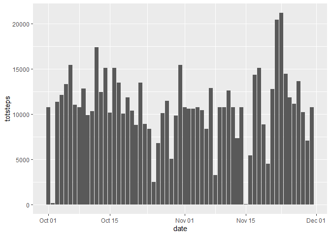

```r
data2 <- data2 %>% group_by(date) %>% mutate(totsteps = sum(steps, na.rm = TRUE))
stepsHistnew <- ggplot(data2, aes(date,totsteps))
stepsHistnew + geom_histogram(stat="identity",position="dodge")
```

For the means and medians,

```r
data2 <- data2 %>% mutate(means = mean(totsteps, na.rm = TRUE))
data2 <- data2 %>% mutate(medians = median(totsteps, na.rm = TRUE))
newavg <- mean(data$means)
newmid <- median(data$medians)
```

## Are there differences in activity patterns between weekdays and weekends?

**Create a new factor variable in the dataset with two levels – “weekday” and “weekend” indicating whether a given date is a weekday or weekend day.**

```r
data2$days <- weekdays(data2$date)
data2 <- data2 %>%
  transform(days = as.factor(case_when(
         days %in% c("Monday", "Tuesday", "Wednesday", "Thursday", "Friday") ~ "Weekdays",
         days %in% c("Saturday", "Sunday") ~ "Weekend"
       )))
str(data2$days)
```

```
##  Factor w/ 2 levels "Weekdays","Weekend": 1 1 1 1 1 1 1 1 1 1 ...
```

**Make a panel plot containing a time series plot (i.e. type = “l”) of the 5-minute interval (x-axis) and the average number of steps taken, averaged across all weekday days or weekend days (y-axis).**

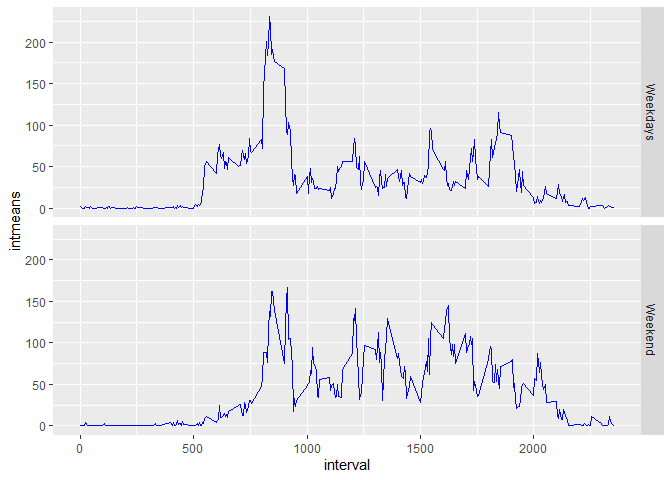

```r
data2 <- ungroup(data2)
#data2 <- transform(my_data, steps = na.aggregate(steps, by = interval))
intdata2 <- data2 %>% group_by(interval, days) %>% mutate(intmeans = mean(steps, na.rm = TRUE))
iplot2 <- ggplot(intdata2, aes(interval, intmeans))
iplot2 +geom_line(color = "blue") + facet_grid(days~.)
```